# My Two-way ANOVA

```r
library(mosaic)
library(DT)
library(pander)
library(car)
library(tidyverse)

# Record your data from your own mini experiment in Excel.
# Save the data as a .csv file in the Data folder of the Statistics-Notebook.

# Read in the data
Reaction_Time <- read_csv("../../Data/Reaction_time.csv")
```

## The Hypothese below is there to compare the Two different levels.

The following two way ANOVA test has been done two compare the results of my reaction time given two levels of variable factors one being reacting with the left hand with one eye shut and the other reaction on the right hand with the second eye shut.

### Factor 1 Eyes

Factor 1: `Eyes` with levels $1$ and $2$.
$$H_0: \mu_{Left} = \mu_{Right}$$
$$H_a: \mu_{Right} \neq \mu_{Right}$$

## Factor 2 Hands

$$H_0: \mu_{Left} = \mu_{Right}$$
$$H_a: \mu_{Left} \neq \mu_{Right}$$

$$H_0: \text{The mean for each level of the Eye factor is the same for
all levels of the Hand factor}$$
$$H_a: \text{The mean for each level of the Eye factor is not the same
for all levels of the Hand factor.}$$

A significance level of $\alpha = 0.05$ will be used for this study.

## This is an ANOVA Two way test to see if the two levels have any effect on my Reaction time.

```r
patrice <- aov(ReactionTime ~ Eye + Hand + Eye:Hand, data = Reaction_Time)



summary(patrice) |> pander()
```

Analysis of Variance Model

|  | Df | Sum Sq | Mean Sq | F value | Pr(>F) |
| --- | --- | --- | --- | --- | --- |
| **Eye** | 1 | 0.003333 | 0.003333 | 1.664 | 0.2332 |
| **Hand** | 1 | 0.002352 | 0.002352 | 1.174 | 0.3102 |
| **Eye:Hand** | 1 | 0.000432 | 0.000432 | 0.2156 | 0.6548 |
| **Residuals** | 8 | 0.01603 | 0.002004 | NA | NA |

## QQ PLot Test for Normality

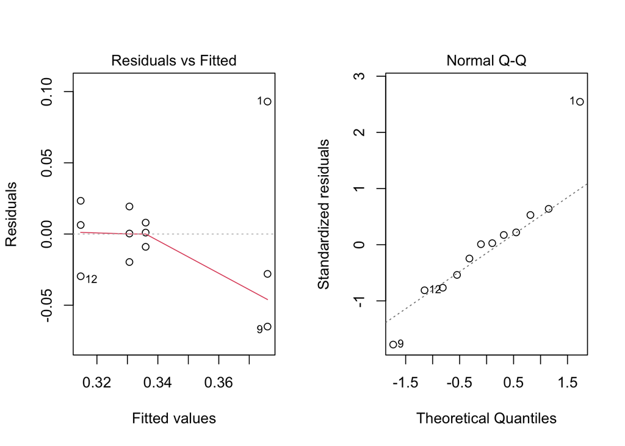

```r
par(mfrow = c(1,2))
plot(patrice, which = 1:2)
```

## QQ Plot Explanation

From the above QQ Plot we can see that the plots show that the data is not normal because there are some outliers on the normal qq on the right hand side. Point 1 and point 9 are very much out of range but this isnt a big problem for the anova test because the requirements arent strict on normality and sample size like the t test.

## Graphical Summary.

### Level 1 Eyes.

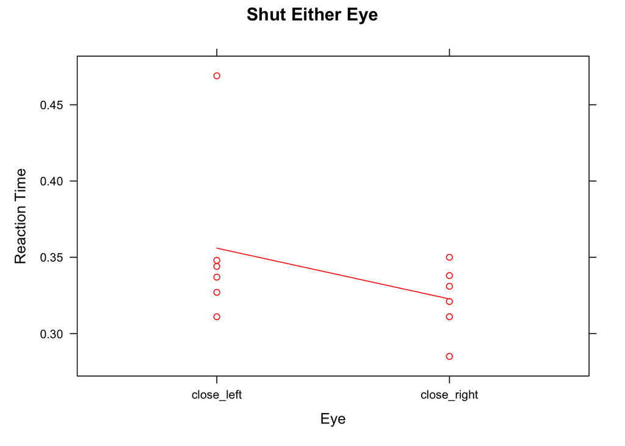

```r
xyplot(ReactionTime ~ as.factor(Eye) , data= Reaction_Time, type=c("p","a"), main="Shut Either Eye", col='red', xlab="Eye", ylab="Reaction Time")
```

### Numerical Summary of First Factor.

```r
Reaction_Time %>%
  group_by(Eye) %>%
  summarise(`Mean Reaction_Time`=mean(ReactionTime)) %>%
  pander(caption="Mean Reactiuon Time With One eye")
```

Mean Reactiuon Time With One eye

| Eye | Mean Reaction_Time |
| --- | --- |
| close_left | 0.356 |
| close_right | 0.3227 |

## Explanation

The right eye closed has a better impact on the reaction time conopared to the left eye given the fact that the left eye has a more delayed reaction time.

### Level 2 Hands

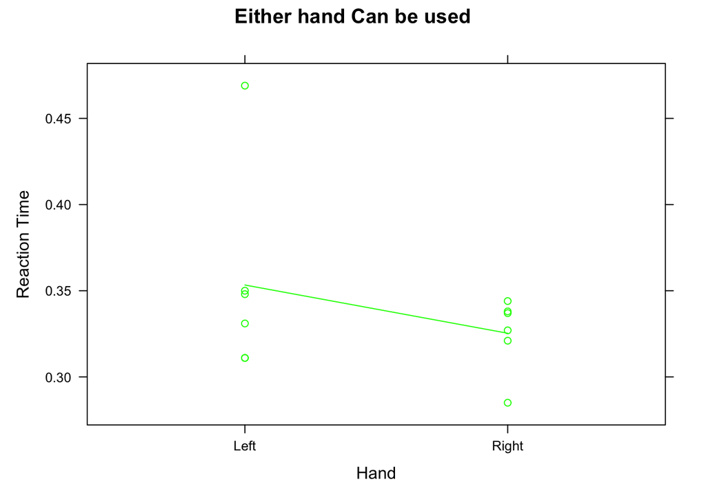

```r
xyplot(ReactionTime ~ as.factor(Hand) , data= Reaction_Time, type=c("p","a"), main="Either hand Can be used", col='green', xlab="Hand", ylab="Reaction Time")
```

### Numeric Summary of Second Factor.

```r
Reaction_Time %>%
  group_by(Hand) %>%
  summarise(`Mean ReactionTime`=mean(ReactionTime)) %>%
  pander(caption="Mean Reaction Time with either Hand")
```

Mean Reaction Time with either Hand

| Hand | Mean ReactionTime |
| --- | --- |
| Left | 0.3533 |
| Right | 0.3253 |

## Explanation

The mean reaction time of the right hand seems to be faster than that of the left hand from the numerical summary. A lower mean time tells us that the reaction time is quicker.

## Interaction of the Two Factors.

### Graphical plot of the two summaries.

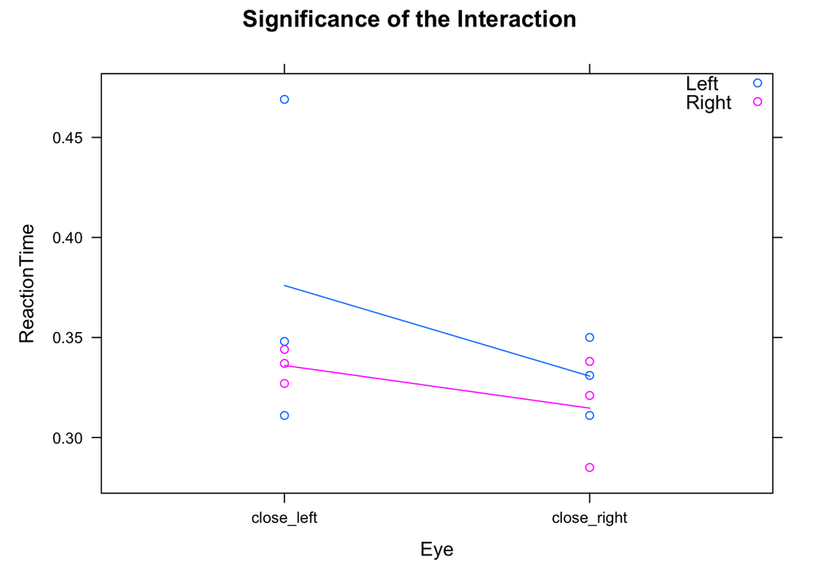

```r
xyplot(ReactionTime ~ as.factor(Eye), data=Reaction_Time, groups= as.factor(Hand), type=c("p","a"), main="Significance of the Interaction",xlab= "Eye" ,auto.key= list(corner=c(1,1)))
```

## Numerical Summary Of Intractions.

```r
Reaction_Time %>%
  group_by(Hand,Eye) %>%
  summarise(ave=mean(ReactionTime), .groups="drop") %>%
 pander(caption="Mean Reaction Time with one Eye open and Either Left Hand or Right Hand")
```

Mean Reaction Time with one Eye open and Either Left Hand or Right Hand

| Hand | Eye | ave |
| --- | --- | --- |
| Left | close_left | 0.376 |
| Left | close_right | 0.3307 |
| Right | close_left | 0.336 |
| Right | close_right | 0.3147 |

## Numeric Summary Explanatin

When we look at the numeric summary of the different levels and the interaction we see that the mean reaction time does differ with the different factors. The right hand with the right eye closed seems to be the lowest mean, meaning its faster reaction and the left eye close using the left hand seems to be the slowest with the highest average.